# Risk Factor Analysis

## Outcome Variable

**Outcome Variable:** y_rate_haz

## Predictor Variables

**Intervention Variable:** nchldlt5

**Adjustment Set:**

unadjusted

## Stratifying Variables

The analysis was stratified on these variable(s):

- agecat
- studyid
- country

## Data Summary

| agecat | studyid | country | nchldlt5 | n_cell | n |
| --- | --- | --- | --- | --- | --- |
| 0-3 months | ki1000108-IRC | INDIA | 1 | 82 | 377 |
| 0-3 months | ki1000108-IRC | INDIA | 2+ | 295 | 377 |
| 0-3 months | ki1017093b-PROVIDE | BANGLADESH | 1 | 471 | 640 |
| 0-3 months | ki1017093b-PROVIDE | BANGLADESH | 2+ | 169 | 640 |
| 0-3 months | ki1017093c-NIH-Crypto | BANGLADESH | 1 | 512 | 721 |
| 0-3 months | ki1017093c-NIH-Crypto | BANGLADESH | 2+ | 209 | 721 |
| 0-3 months | kiGH5241-JiVitA-3 | BANGLADESH | 1 | 6122 | 9815 |
| 0-3 months | kiGH5241-JiVitA-3 | BANGLADESH | 2+ | 3693 | 9815 |
| 3-6 months | ki1000108-IRC | INDIA | 1 | 87 | 397 |
| 3-6 months | ki1000108-IRC | INDIA | 2+ | 310 | 397 |
| 3-6 months | ki1017093b-PROVIDE | BANGLADESH | 1 | 434 | 598 |
| 3-6 months | ki1017093b-PROVIDE | BANGLADESH | 2+ | 164 | 598 |
| 3-6 months | ki1017093c-NIH-Crypto | BANGLADESH | 1 | 492 | 695 |
| 3-6 months | ki1017093c-NIH-Crypto | BANGLADESH | 2+ | 203 | 695 |
| 3-6 months | ki1066203-TanzaniaChild2 | TANZANIA, UNITED REPUBLIC OF | 1 | 1146 | 1656 |
| 3-6 months | ki1066203-TanzaniaChild2 | TANZANIA, UNITED REPUBLIC OF | 2+ | 510 | 1656 |
| 3-6 months | kiGH5241-JiVitA-3 | BANGLADESH | 1 | 4014 | 6234 |
| 3-6 months | kiGH5241-JiVitA-3 | BANGLADESH | 2+ | 2220 | 6234 |
| 6-9 months | ki1000108-IRC | INDIA | 1 | 89 | 407 |
| 6-9 months | ki1000108-IRC | INDIA | 2+ | 318 | 407 |
| 6-9 months | ki1017093b-PROVIDE | BANGLADESH | 1 | 410 | 565 |
| 6-9 months | ki1017093b-PROVIDE | BANGLADESH | 2+ | 155 | 565 |
| 6-9 months | ki1017093c-NIH-Crypto | BANGLADESH | 1 | 488 | 688 |
| 6-9 months | ki1017093c-NIH-Crypto | BANGLADESH | 2+ | 200 | 688 |
| 6-9 months | ki1066203-TanzaniaChild2 | TANZANIA, UNITED REPUBLIC OF | 1 | 1036 | 1480 |
| 6-9 months | ki1066203-TanzaniaChild2 | TANZANIA, UNITED REPUBLIC OF | 2+ | 444 | 1480 |
| 6-9 months | ki1148112-LCNI-5 | MALAWI | 1 | 261 | 557 |
| 6-9 months | ki1148112-LCNI-5 | MALAWI | 2+ | 296 | 557 |
| 9-12 months | ki1000108-IRC | INDIA | 1 | 88 | 400 |
| 9-12 months | ki1000108-IRC | INDIA | 2+ | 312 | 400 |
| 9-12 months | ki1017093b-PROVIDE | BANGLADESH | 1 | 413 | 566 |
| 9-12 months | ki1017093b-PROVIDE | BANGLADESH | 2+ | 153 | 566 |
| 9-12 months | ki1017093c-NIH-Crypto | BANGLADESH | 1 | 475 | 674 |
| 9-12 months | ki1017093c-NIH-Crypto | BANGLADESH | 2+ | 199 | 674 |
| 9-12 months | ki1066203-TanzaniaChild2 | TANZANIA, UNITED REPUBLIC OF | 1 | 764 | 1075 |
| 9-12 months | ki1066203-TanzaniaChild2 | TANZANIA, UNITED REPUBLIC OF | 2+ | 311 | 1075 |
| 9-12 months | ki1148112-LCNI-5 | MALAWI | 1 | 179 | 383 |
| 9-12 months | ki1148112-LCNI-5 | MALAWI | 2+ | 204 | 383 |
| 12-15 months | ki1000108-IRC | INDIA | 1 | 82 | 390 |
| 12-15 months | ki1000108-IRC | INDIA | 2+ | 308 | 390 |
| 12-15 months | ki1017093b-PROVIDE | BANGLADESH | 1 | 391 | 532 |
| 12-15 months | ki1017093b-PROVIDE | BANGLADESH | 2+ | 141 | 532 |
| 12-15 months | ki1017093c-NIH-Crypto | BANGLADESH | 1 | 463 | 660 |
| 12-15 months | ki1017093c-NIH-Crypto | BANGLADESH | 2+ | 197 | 660 |
| 12-15 months | ki1066203-TanzaniaChild2 | TANZANIA, UNITED REPUBLIC OF | 1 | 570 | 786 |
| 12-15 months | ki1066203-TanzaniaChild2 | TANZANIA, UNITED REPUBLIC OF | 2+ | 216 | 786 |
| 12-15 months | ki1148112-LCNI-5 | MALAWI | 1 | 52 | 125 |
| 12-15 months | ki1148112-LCNI-5 | MALAWI | 2+ | 73 | 125 |
| 15-18 months | ki1000108-IRC | INDIA | 1 | 78 | 382 |
| 15-18 months | ki1000108-IRC | INDIA | 2+ | 304 | 382 |
| 15-18 months | ki1017093b-PROVIDE | BANGLADESH | 1 | 388 | 528 |
| 15-18 months | ki1017093b-PROVIDE | BANGLADESH | 2+ | 140 | 528 |
| 15-18 months | ki1017093c-NIH-Crypto | BANGLADESH | 1 | 425 | 604 |
| 15-18 months | ki1017093c-NIH-Crypto | BANGLADESH | 2+ | 179 | 604 |
| 15-18 months | ki1066203-TanzaniaChild2 | TANZANIA, UNITED REPUBLIC OF | 1 | 481 | 662 |
| 15-18 months | ki1066203-TanzaniaChild2 | TANZANIA, UNITED REPUBLIC OF | 2+ | 181 | 662 |
| 15-18 months | ki1148112-LCNI-5 | MALAWI | 1 | 51 | 118 |
| 15-18 months | ki1148112-LCNI-5 | MALAWI | 2+ | 67 | 118 |
| 18-21 months | ki1000108-IRC | INDIA | 1 | 82 | 379 |
| 18-21 months | ki1000108-IRC | INDIA | 2+ | 297 | 379 |
| 18-21 months | ki1017093b-PROVIDE | BANGLADESH | 1 | 394 | 541 |
| 18-21 months | ki1017093b-PROVIDE | BANGLADESH | 2+ | 147 | 541 |
| 18-21 months | ki1017093c-NIH-Crypto | BANGLADESH | 1 | 387 | 546 |
| 18-21 months | ki1017093c-NIH-Crypto | BANGLADESH | 2+ | 159 | 546 |
| 18-21 months | ki1066203-TanzaniaChild2 | TANZANIA, UNITED REPUBLIC OF | 1 | 8 | 9 |
| 18-21 months | ki1066203-TanzaniaChild2 | TANZANIA, UNITED REPUBLIC OF | 2+ | 1 | 9 |
| 18-21 months | ki1148112-LCNI-5 | MALAWI | 1 | 241 | 472 |
| 18-21 months | ki1148112-LCNI-5 | MALAWI | 2+ | 231 | 472 |
| 21-24 months | ki1000108-IRC | INDIA | 1 | 84 | 389 |
| 21-24 months | ki1000108-IRC | INDIA | 2+ | 305 | 389 |
| 21-24 months | ki1017093b-PROVIDE | BANGLADESH | 1 | 342 | 471 |
| 21-24 months | ki1017093b-PROVIDE | BANGLADESH | 2+ | 129 | 471 |
| 21-24 months | ki1017093c-NIH-Crypto | BANGLADESH | 1 | 340 | 490 |
| 21-24 months | ki1017093c-NIH-Crypto | BANGLADESH | 2+ | 150 | 490 |
| 21-24 months | ki1148112-LCNI-5 | MALAWI | 1 | 213 | 403 |
| 21-24 months | ki1148112-LCNI-5 | MALAWI | 2+ | 190 | 403 |

The following strata were considered:

- agecat: 0-3 months, studyid: ki1000108-IRC, country: INDIA
- agecat: 0-3 months, studyid: ki1017093b-PROVIDE, country: BANGLADESH
- agecat: 0-3 months, studyid: ki1017093c-NIH-Crypto, country: BANGLADESH
- agecat: 0-3 months, studyid: kiGH5241-JiVitA-3, country: BANGLADESH
- agecat: 12-15 months, studyid: ki1000108-IRC, country: INDIA
- agecat: 12-15 months, studyid: ki1017093b-PROVIDE, country: BANGLADESH
- agecat: 12-15 months, studyid: ki1017093c-NIH-Crypto, country: BANGLADESH
- agecat: 12-15 months, studyid: ki1066203-TanzaniaChild2, country: TANZANIA, UNITED REPUBLIC OF
- agecat: 12-15 months, studyid: ki1148112-LCNI-5, country: MALAWI
- agecat: 15-18 months, studyid: ki1000108-IRC, country: INDIA
- agecat: 15-18 months, studyid: ki1017093b-PROVIDE, country: BANGLADESH
- agecat: 15-18 months, studyid: ki1017093c-NIH-Crypto, country: BANGLADESH
- agecat: 15-18 months, studyid: ki1066203-TanzaniaChild2, country: TANZANIA, UNITED REPUBLIC OF
- agecat: 15-18 months, studyid: ki1148112-LCNI-5, country: MALAWI
- agecat: 18-21 months, studyid: ki1000108-IRC, country: INDIA
- agecat: 18-21 months, studyid: ki1017093b-PROVIDE, country: BANGLADESH
- agecat: 18-21 months, studyid: ki1017093c-NIH-Crypto, country: BANGLADESH
- agecat: 18-21 months, studyid: ki1066203-TanzaniaChild2, country: TANZANIA, UNITED REPUBLIC OF
- agecat: 18-21 months, studyid: ki1148112-LCNI-5, country: MALAWI
- agecat: 21-24 months, studyid: ki1000108-IRC, country: INDIA
- agecat: 21-24 months, studyid: ki1017093b-PROVIDE, country: BANGLADESH
- agecat: 21-24 months, studyid: ki1017093c-NIH-Crypto, country: BANGLADESH
- agecat: 21-24 months, studyid: ki1148112-LCNI-5, country: MALAWI
- agecat: 3-6 months, studyid: ki1000108-IRC, country: INDIA
- agecat: 3-6 months, studyid: ki1017093b-PROVIDE, country: BANGLADESH
- agecat: 3-6 months, studyid: ki1017093c-NIH-Crypto, country: BANGLADESH
- agecat: 3-6 months, studyid: ki1066203-TanzaniaChild2, country: TANZANIA, UNITED REPUBLIC OF
- agecat: 3-6 months, studyid: kiGH5241-JiVitA-3, country: BANGLADESH
- agecat: 6-9 months, studyid: ki1000108-IRC, country: INDIA
- agecat: 6-9 months, studyid: ki1017093b-PROVIDE, country: BANGLADESH
- agecat: 6-9 months, studyid: ki1017093c-NIH-Crypto, country: BANGLADESH
- agecat: 6-9 months, studyid: ki1066203-TanzaniaChild2, country: TANZANIA, UNITED REPUBLIC OF
- agecat: 6-9 months, studyid: ki1148112-LCNI-5, country: MALAWI
- agecat: 9-12 months, studyid: ki1000108-IRC, country: INDIA
- agecat: 9-12 months, studyid: ki1017093b-PROVIDE, country: BANGLADESH
- agecat: 9-12 months, studyid: ki1017093c-NIH-Crypto, country: BANGLADESH
- agecat: 9-12 months, studyid: ki1066203-TanzaniaChild2, country: TANZANIA, UNITED REPUBLIC OF
- agecat: 9-12 months, studyid: ki1148112-LCNI-5, country: MALAWI

### Dropped Strata

Some strata were dropped due to rare outcomes:

- agecat: 18-21 months, studyid: ki1066203-TanzaniaChild2, country: TANZANIA, UNITED REPUBLIC OF

## Methods Detail

We’re interested in the causal parameters $E[Y_a]$ for all values of $a \in \mathcal{A}$. These parameters represent the mean outcome if, possibly contrary to fact, we intervened to set all units to have $A=a$. Under the randomization and positivity assumptions, these are identified by the statistical parameters $\psi_a=E_W[E_{Y|A,W}(Y|A=a,W)]$. In addition, we’re interested in the mean of $Y$, $E[Y]$ under no intervention (the observed mean). We will estimate these parameters by using SuperLearner to fit the relevant likelihood factors – $E_{Y|A,W}(Y|A=a,W)$ and $p(A=a|W)$, and then updating our likelihood fit using a joint TMLE.

For unadjusted analyses ($W=\{\}$), initial likelihoods were estimated using Lrnr_glm to estimate the simple $E(Y|A)$ and Lrnr_mean to estimate $p(A)$. For adjusted analyses, a small library containing Lrnr_glmnet, Lrnr_xgboost, and Lrnr_mean was used.

Having estimated these parameters, we will then use the delta method to estimate relative risks and attributable risks relative to a prespecified baseline level of $A$.

# Results Detail

## Results Plots

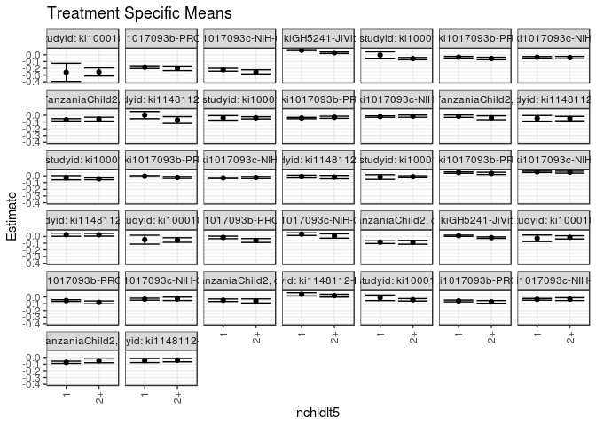

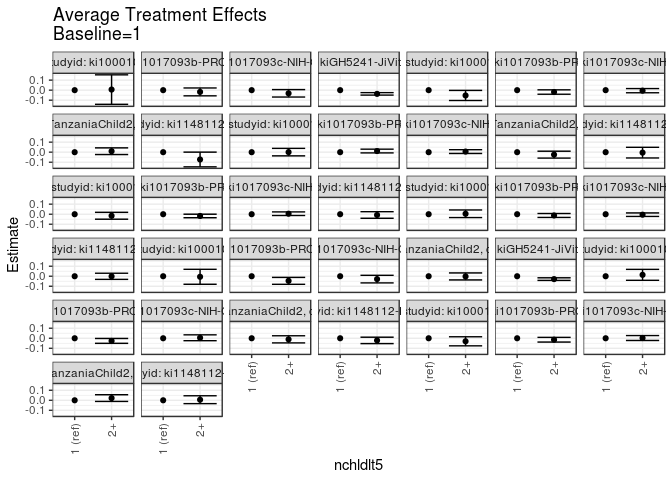

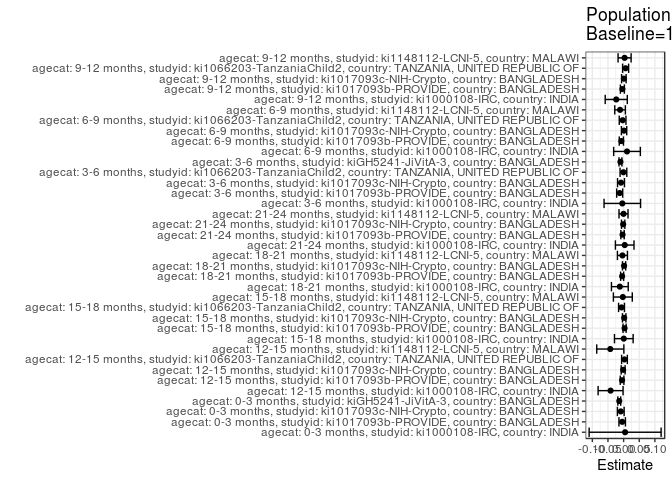

## Results Table

### Parameter: TSM

| agecat | studyid | country | intervention_level | baseline_level | estimate | ci_lower | ci_upper |
| --- | --- | --- | --- | --- | --- | --- | --- |
| 0-3 months | ki1000108-IRC | INDIA | 1 | NA | -0.2606104 | -0.3947714 | -0.1264493 |
| 0-3 months | ki1000108-IRC | INDIA | 2+ | NA | -0.2544975 | -0.3145570 | -0.1944381 |
| 0-3 months | ki1017093b-PROVIDE | BANGLADESH | 1 | NA | -0.1834612 | -0.2037302 | -0.1631922 |
| 0-3 months | ki1017093b-PROVIDE | BANGLADESH | 2+ | NA | -0.2008018 | -0.2344406 | -0.1671630 |
| 0-3 months | ki1017093c-NIH-Crypto | BANGLADESH | 1 | NA | -0.2221284 | -0.2432235 | -0.2010334 |
| 0-3 months | ki1017093c-NIH-Crypto | BANGLADESH | 2+ | NA | -0.2536327 | -0.2840412 | -0.2232242 |
| 0-3 months | kiGH5241-JiVitA-3 | BANGLADESH | 1 | NA | 0.0671883 | 0.0588502 | 0.0755265 |
| 0-3 months | kiGH5241-JiVitA-3 | BANGLADESH | 2+ | NA | 0.0302095 | 0.0191502 | 0.0412688 |
| 3-6 months | ki1000108-IRC | INDIA | 1 | NA | -0.0477002 | -0.1144155 | 0.0190151 |
| 3-6 months | ki1000108-IRC | INDIA | 2+ | NA | -0.0530682 | -0.0867517 | -0.0193846 |
| 3-6 months | ki1017093b-PROVIDE | BANGLADESH | 1 | NA | -0.0143933 | -0.0332955 | 0.0045089 |
| 3-6 months | ki1017093b-PROVIDE | BANGLADESH | 2+ | NA | -0.0602249 | -0.0889216 | -0.0315281 |
| 3-6 months | ki1017093c-NIH-Crypto | BANGLADESH | 1 | NA | 0.0351356 | 0.0155221 | 0.0547491 |
| 3-6 months | ki1017093c-NIH-Crypto | BANGLADESH | 2+ | NA | 0.0065085 | -0.0257871 | 0.0388041 |
| 3-6 months | ki1066203-TanzaniaChild2 | TANZANIA, UNITED REPUBLIC OF | 1 | NA | -0.0850525 | -0.1054841 | -0.0646210 |
| 3-6 months | ki1066203-TanzaniaChild2 | TANZANIA, UNITED REPUBLIC OF | 2+ | NA | -0.0870272 | -0.1153180 | -0.0587365 |
| 3-6 months | kiGH5241-JiVitA-3 | BANGLADESH | 1 | NA | 0.0109692 | 0.0025367 | 0.0194018 |
| 3-6 months | kiGH5241-JiVitA-3 | BANGLADESH | 2+ | NA | -0.0175771 | -0.0282258 | -0.0069285 |
| 6-9 months | ki1000108-IRC | INDIA | 1 | NA | -0.0271259 | -0.0761987 | 0.0219468 |
| 6-9 months | ki1000108-IRC | INDIA | 2+ | NA | -0.0132287 | -0.0371996 | 0.0107421 |
| 6-9 months | ki1017093b-PROVIDE | BANGLADESH | 1 | NA | -0.0542021 | -0.0668739 | -0.0415303 |
| 6-9 months | ki1017093b-PROVIDE | BANGLADESH | 2+ | NA | -0.0805357 | -0.1011768 | -0.0598947 |
| 6-9 months | ki1017093c-NIH-Crypto | BANGLADESH | 1 | NA | -0.0327946 | -0.0475065 | -0.0180827 |
| 6-9 months | ki1017093c-NIH-Crypto | BANGLADESH | 2+ | NA | -0.0278725 | -0.0530777 | -0.0026673 |
| 6-9 months | ki1066203-TanzaniaChild2 | TANZANIA, UNITED REPUBLIC OF | 1 | NA | -0.0484279 | -0.0673998 | -0.0294560 |
| 6-9 months | ki1066203-TanzaniaChild2 | TANZANIA, UNITED REPUBLIC OF | 2+ | NA | -0.0591837 | -0.0894299 | -0.0289375 |
| 6-9 months | ki1148112-LCNI-5 | MALAWI | 1 | NA | 0.0404781 | 0.0165477 | 0.0644084 |
| 6-9 months | ki1148112-LCNI-5 | MALAWI | 2+ | NA | 0.0191651 | -0.0019361 | 0.0402663 |
| 9-12 months | ki1000108-IRC | INDIA | 1 | NA | -0.0125936 | -0.0539576 | 0.0287704 |
| 9-12 months | ki1000108-IRC | INDIA | 2+ | NA | -0.0427701 | -0.0610144 | -0.0245259 |
| 9-12 months | ki1017093b-PROVIDE | BANGLADESH | 1 | NA | -0.0591561 | -0.0723252 | -0.0459870 |
| 9-12 months | ki1017093b-PROVIDE | BANGLADESH | 2+ | NA | -0.0735500 | -0.0930391 | -0.0540610 |
| 9-12 months | ki1017093c-NIH-Crypto | BANGLADESH | 1 | NA | -0.0350398 | -0.0478914 | -0.0221882 |
| 9-12 months | ki1017093c-NIH-Crypto | BANGLADESH | 2+ | NA | -0.0325323 | -0.0533142 | -0.0117505 |
| 9-12 months | ki1066203-TanzaniaChild2 | TANZANIA, UNITED REPUBLIC OF | 1 | NA | -0.0723549 | -0.0886095 | -0.0561004 |
| 9-12 months | ki1066203-TanzaniaChild2 | TANZANIA, UNITED REPUBLIC OF | 2+ | NA | -0.0503074 | -0.0793197 | -0.0212951 |
| 9-12 months | ki1148112-LCNI-5 | MALAWI | 1 | NA | -0.0464251 | -0.0765736 | -0.0162765 |
| 9-12 months | ki1148112-LCNI-5 | MALAWI | 2+ | NA | -0.0405843 | -0.0655615 | -0.0156071 |
| 12-15 months | ki1000108-IRC | INDIA | 1 | NA | -0.0037839 | -0.0513049 | 0.0437371 |
| 12-15 months | ki1000108-IRC | INDIA | 2+ | NA | -0.0565453 | -0.0733553 | -0.0397354 |
| 12-15 months | ki1017093b-PROVIDE | BANGLADESH | 1 | NA | -0.0359896 | -0.0480053 | -0.0239738 |
| 12-15 months | ki1017093b-PROVIDE | BANGLADESH | 2+ | NA | -0.0545574 | -0.0728192 | -0.0362955 |
| 12-15 months | ki1017093c-NIH-Crypto | BANGLADESH | 1 | NA | -0.0368279 | -0.0480417 | -0.0256142 |
| 12-15 months | ki1017093c-NIH-Crypto | BANGLADESH | 2+ | NA | -0.0418647 | -0.0596029 | -0.0241264 |
| 12-15 months | ki1066203-TanzaniaChild2 | TANZANIA, UNITED REPUBLIC OF | 1 | NA | -0.0671265 | -0.0838455 | -0.0504075 |
| 12-15 months | ki1066203-TanzaniaChild2 | TANZANIA, UNITED REPUBLIC OF | 2+ | NA | -0.0572406 | -0.0860349 | -0.0284464 |
| 12-15 months | ki1148112-LCNI-5 | MALAWI | 1 | NA | 0.0026093 | -0.0510097 | 0.0562282 |
| 12-15 months | ki1148112-LCNI-5 | MALAWI | 2+ | NA | -0.0702995 | -0.1204814 | -0.0201176 |
| 15-18 months | ki1000108-IRC | INDIA | 1 | NA | -0.0391017 | -0.0728197 | -0.0053837 |
| 15-18 months | ki1000108-IRC | INDIA | 2+ | NA | -0.0383665 | -0.0546606 | -0.0220725 |
| 15-18 months | ki1017093b-PROVIDE | BANGLADESH | 1 | NA | -0.0406775 | -0.0511652 | -0.0301899 |
| 15-18 months | ki1017093b-PROVIDE | BANGLADESH | 2+ | NA | -0.0292357 | -0.0447329 | -0.0137386 |
| 15-18 months | ki1017093c-NIH-Crypto | BANGLADESH | 1 | NA | -0.0187218 | -0.0284624 | -0.0089811 |
| 15-18 months | ki1017093c-NIH-Crypto | BANGLADESH | 2+ | NA | -0.0125994 | -0.0286649 | 0.0034661 |
| 15-18 months | ki1066203-TanzaniaChild2 | TANZANIA, UNITED REPUBLIC OF | 1 | NA | -0.0127024 | -0.0306153 | 0.0052105 |
| 15-18 months | ki1066203-TanzaniaChild2 | TANZANIA, UNITED REPUBLIC OF | 2+ | NA | -0.0371541 | -0.0665008 | -0.0078074 |
| 15-18 months | ki1148112-LCNI-5 | MALAWI | 1 | NA | -0.0449398 | -0.0869498 | -0.0029298 |
| 15-18 months | ki1148112-LCNI-5 | MALAWI | 2+ | NA | -0.0493112 | -0.0819455 | -0.0166770 |
| 18-21 months | ki1000108-IRC | INDIA | 1 | NA | -0.0279886 | -0.0589172 | 0.0029400 |
| 18-21 months | ki1000108-IRC | INDIA | 2+ | NA | -0.0434205 | -0.0580094 | -0.0288315 |
| 18-21 months | ki1017093b-PROVIDE | BANGLADESH | 1 | NA | -0.0061858 | -0.0159348 | 0.0035631 |
| 18-21 months | ki1017093b-PROVIDE | BANGLADESH | 2+ | NA | -0.0236821 | -0.0382740 | -0.0090902 |
| 18-21 months | ki1017093c-NIH-Crypto | BANGLADESH | 1 | NA | -0.0294286 | -0.0388894 | -0.0199678 |
| 18-21 months | ki1017093c-NIH-Crypto | BANGLADESH | 2+ | NA | -0.0244155 | -0.0395905 | -0.0092405 |
| 18-21 months | ki1148112-LCNI-5 | MALAWI | 1 | NA | -0.0106793 | -0.0315861 | 0.0102276 |
| 18-21 months | ki1148112-LCNI-5 | MALAWI | 2+ | NA | -0.0184168 | -0.0435244 | 0.0066908 |
| 21-24 months | ki1000108-IRC | INDIA | 1 | NA | -0.0173810 | -0.0523999 | 0.0176379 |
| 21-24 months | ki1000108-IRC | INDIA | 2+ | NA | -0.0129517 | -0.0273213 | 0.0014179 |
| 21-24 months | ki1017093b-PROVIDE | BANGLADESH | 1 | NA | 0.0496631 | 0.0396110 | 0.0597152 |
| 21-24 months | ki1017093b-PROVIDE | BANGLADESH | 2+ | NA | 0.0371436 | 0.0203163 | 0.0539709 |
| 21-24 months | ki1017093c-NIH-Crypto | BANGLADESH | 1 | NA | 0.0602027 | 0.0501510 | 0.0702545 |
| 21-24 months | ki1017093c-NIH-Crypto | BANGLADESH | 2+ | NA | 0.0554966 | 0.0412350 | 0.0697583 |
| 21-24 months | ki1148112-LCNI-5 | MALAWI | 1 | NA | 0.0258111 | 0.0027251 | 0.0488971 |
| 21-24 months | ki1148112-LCNI-5 | MALAWI | 2+ | NA | 0.0251003 | 0.0051844 | 0.0450162 |

### Parameter: E(Y)

| agecat | studyid | country | intervention_level | baseline_level | estimate | ci_lower | ci_upper |
| --- | --- | --- | --- | --- | --- | --- | --- |
| 0-3 months | ki1000108-IRC | INDIA | NA | NA | -0.2558271 | -0.3111464 | -0.2005078 |
| 0-3 months | ki1017093b-PROVIDE | BANGLADESH | NA | NA | -0.1880402 | -0.2054115 | -0.1706689 |
| 0-3 months | ki1017093c-NIH-Crypto | BANGLADESH | NA | NA | -0.2312607 | -0.2486732 | -0.2138483 |
| 0-3 months | kiGH5241-JiVitA-3 | BANGLADESH | NA | NA | 0.0532747 | 0.0458052 | 0.0607441 |
| 3-6 months | ki1000108-IRC | INDIA | NA | NA | -0.0518918 | -0.0819849 | -0.0217987 |
| 3-6 months | ki1017093b-PROVIDE | BANGLADESH | NA | NA | -0.0269625 | -0.0428628 | -0.0110622 |
| 3-6 months | ki1017093c-NIH-Crypto | BANGLADESH | NA | NA | 0.0267740 | 0.0099602 | 0.0435879 |
| 3-6 months | ki1066203-TanzaniaChild2 | TANZANIA, UNITED REPUBLIC OF | NA | NA | -0.0856607 | -0.1022688 | -0.0690525 |
| 3-6 months | kiGH5241-JiVitA-3 | BANGLADESH | NA | NA | 0.0008035 | -0.0061473 | 0.0077544 |
| 6-9 months | ki1000108-IRC | INDIA | NA | NA | -0.0162677 | -0.0378604 | 0.0053250 |
| 6-9 months | ki1017093b-PROVIDE | BANGLADESH | NA | NA | -0.0614264 | -0.0722690 | -0.0505838 |
| 6-9 months | ki1017093c-NIH-Crypto | BANGLADESH | NA | NA | -0.0313638 | -0.0441155 | -0.0186120 |
| 6-9 months | ki1066203-TanzaniaChild2 | TANZANIA, UNITED REPUBLIC OF | NA | NA | -0.0516546 | -0.0677408 | -0.0355685 |
| 6-9 months | ki1148112-LCNI-5 | MALAWI | NA | NA | 0.0291520 | 0.0132692 | 0.0450348 |
| 9-12 months | ki1000108-IRC | INDIA | NA | NA | -0.0361313 | -0.0530672 | -0.0191954 |
| 9-12 months | ki1017093b-PROVIDE | BANGLADESH | NA | NA | -0.0630470 | -0.0740183 | -0.0520757 |
| 9-12 months | ki1017093c-NIH-Crypto | BANGLADESH | NA | NA | -0.0342995 | -0.0452397 | -0.0233593 |
| 9-12 months | ki1066203-TanzaniaChild2 | TANZANIA, UNITED REPUBLIC OF | NA | NA | -0.0659765 | -0.0802683 | -0.0516847 |
| 9-12 months | ki1148112-LCNI-5 | MALAWI | NA | NA | -0.0433141 | -0.0626948 | -0.0239333 |
| 12-15 months | ki1000108-IRC | INDIA | NA | NA | -0.0454519 | -0.0622041 | -0.0286997 |
| 12-15 months | ki1017093b-PROVIDE | BANGLADESH | NA | NA | -0.0409107 | -0.0510053 | -0.0308161 |
| 12-15 months | ki1017093c-NIH-Crypto | BANGLADESH | NA | NA | -0.0383313 | -0.0478154 | -0.0288473 |
| 12-15 months | ki1066203-TanzaniaChild2 | TANZANIA, UNITED REPUBLIC OF | NA | NA | -0.0644098 | -0.0788912 | -0.0499283 |
| 12-15 months | ki1148112-LCNI-5 | MALAWI | NA | NA | -0.0399695 | -0.0773378 | -0.0026011 |
| 15-18 months | ki1000108-IRC | INDIA | NA | NA | -0.0385167 | -0.0531981 | -0.0238352 |
| 15-18 months | ki1017093b-PROVIDE | BANGLADESH | NA | NA | -0.0376437 | -0.0463882 | -0.0288992 |
| 15-18 months | ki1017093c-NIH-Crypto | BANGLADESH | NA | NA | -0.0169074 | -0.0252557 | -0.0085590 |
| 15-18 months | ki1066203-TanzaniaChild2 | TANZANIA, UNITED REPUBLIC OF | NA | NA | -0.0193878 | -0.0347002 | -0.0040754 |
| 15-18 months | ki1148112-LCNI-5 | MALAWI | NA | NA | -0.0474219 | -0.0733675 | -0.0214763 |
| 18-21 months | ki1000108-IRC | INDIA | NA | NA | -0.0400816 | -0.0533440 | -0.0268193 |
| 18-21 months | ki1017093b-PROVIDE | BANGLADESH | NA | NA | -0.0109399 | -0.0190984 | -0.0027814 |
| 18-21 months | ki1017093c-NIH-Crypto | BANGLADESH | NA | NA | -0.0279687 | -0.0360019 | -0.0199355 |
| 18-21 months | ki1148112-LCNI-5 | MALAWI | NA | NA | -0.0144661 | -0.0307469 | 0.0018148 |
| 21-24 months | ki1000108-IRC | INDIA | NA | NA | -0.0139081 | -0.0274784 | -0.0003379 |
| 21-24 months | ki1017093b-PROVIDE | BANGLADESH | NA | NA | 0.0462342 | 0.0375872 | 0.0548812 |
| 21-24 months | ki1017093c-NIH-Crypto | BANGLADESH | NA | NA | 0.0587621 | 0.0505315 | 0.0669927 |
| 21-24 months | ki1148112-LCNI-5 | MALAWI | NA | NA | 0.0254759 | 0.0100795 | 0.0408724 |

### Parameter: ATE

| agecat | studyid | country | intervention_level | baseline_level | estimate | ci_lower | ci_upper |
| --- | --- | --- | --- | --- | --- | --- | --- |
| 0-3 months | ki1000108-IRC | INDIA | 1 | 1 | 0.0000000 | 0.0000000 | 0.0000000 |
| 0-3 months | ki1000108-IRC | INDIA | 2+ | 1 | 0.0061128 | -0.1408781 | 0.1531037 |
| 0-3 months | ki1017093b-PROVIDE | BANGLADESH | 1 | 1 | 0.0000000 | 0.0000000 | 0.0000000 |
| 0-3 months | ki1017093b-PROVIDE | BANGLADESH | 2+ | 1 | -0.0173406 | -0.0566140 | 0.0219328 |
| 0-3 months | ki1017093c-NIH-Crypto | BANGLADESH | 1 | 1 | 0.0000000 | 0.0000000 | 0.0000000 |
| 0-3 months | ki1017093c-NIH-Crypto | BANGLADESH | 2+ | 1 | -0.0315043 | -0.0685135 | 0.0055048 |
| 0-3 months | kiGH5241-JiVitA-3 | BANGLADESH | 1 | 1 | 0.0000000 | 0.0000000 | 0.0000000 |
| 0-3 months | kiGH5241-JiVitA-3 | BANGLADESH | 2+ | 1 | -0.0369788 | -0.0491990 | -0.0247586 |
| 3-6 months | ki1000108-IRC | INDIA | 1 | 1 | 0.0000000 | 0.0000000 | 0.0000000 |
| 3-6 months | ki1000108-IRC | INDIA | 2+ | 1 | -0.0053679 | -0.0801042 | 0.0693684 |
| 3-6 months | ki1017093b-PROVIDE | BANGLADESH | 1 | 1 | 0.0000000 | 0.0000000 | 0.0000000 |
| 3-6 months | ki1017093b-PROVIDE | BANGLADESH | 2+ | 1 | -0.0458316 | -0.0801943 | -0.0114688 |
| 3-6 months | ki1017093c-NIH-Crypto | BANGLADESH | 1 | 1 | 0.0000000 | 0.0000000 | 0.0000000 |
| 3-6 months | ki1017093c-NIH-Crypto | BANGLADESH | 2+ | 1 | -0.0286271 | -0.0664120 | 0.0091578 |
| 3-6 months | ki1066203-TanzaniaChild2 | TANZANIA, UNITED REPUBLIC OF | 1 | 1 | 0.0000000 | 0.0000000 | 0.0000000 |
| 3-6 months | ki1066203-TanzaniaChild2 | TANZANIA, UNITED REPUBLIC OF | 2+ | 1 | -0.0019747 | -0.0368719 | 0.0329225 |
| 3-6 months | kiGH5241-JiVitA-3 | BANGLADESH | 1 | 1 | 0.0000000 | 0.0000000 | 0.0000000 |
| 3-6 months | kiGH5241-JiVitA-3 | BANGLADESH | 2+ | 1 | -0.0285464 | -0.0414921 | -0.0156007 |
| 6-9 months | ki1000108-IRC | INDIA | 1 | 1 | 0.0000000 | 0.0000000 | 0.0000000 |
| 6-9 months | ki1000108-IRC | INDIA | 2+ | 1 | 0.0138972 | -0.0407173 | 0.0685117 |
| 6-9 months | ki1017093b-PROVIDE | BANGLADESH | 1 | 1 | 0.0000000 | 0.0000000 | 0.0000000 |
| 6-9 months | ki1017093b-PROVIDE | BANGLADESH | 2+ | 1 | -0.0263336 | -0.0505540 | -0.0021132 |
| 6-9 months | ki1017093c-NIH-Crypto | BANGLADESH | 1 | 1 | 0.0000000 | 0.0000000 | 0.0000000 |
| 6-9 months | ki1017093c-NIH-Crypto | BANGLADESH | 2+ | 1 | 0.0049221 | -0.0242625 | 0.0341067 |
| 6-9 months | ki1066203-TanzaniaChild2 | TANZANIA, UNITED REPUBLIC OF | 1 | 1 | 0.0000000 | 0.0000000 | 0.0000000 |
| 6-9 months | ki1066203-TanzaniaChild2 | TANZANIA, UNITED REPUBLIC OF | 2+ | 1 | -0.0107558 | -0.0464597 | 0.0249480 |
| 6-9 months | ki1148112-LCNI-5 | MALAWI | 1 | 1 | 0.0000000 | 0.0000000 | 0.0000000 |
| 6-9 months | ki1148112-LCNI-5 | MALAWI | 2+ | 1 | -0.0213129 | -0.0532178 | 0.0105920 |
| 9-12 months | ki1000108-IRC | INDIA | 1 | 1 | 0.0000000 | 0.0000000 | 0.0000000 |
| 9-12 months | ki1000108-IRC | INDIA | 2+ | 1 | -0.0301766 | -0.0753853 | 0.0150322 |
| 9-12 months | ki1017093b-PROVIDE | BANGLADESH | 1 | 1 | 0.0000000 | 0.0000000 | 0.0000000 |
| 9-12 months | ki1017093b-PROVIDE | BANGLADESH | 2+ | 1 | -0.0143940 | -0.0379152 | 0.0091273 |
| 9-12 months | ki1017093c-NIH-Crypto | BANGLADESH | 1 | 1 | 0.0000000 | 0.0000000 | 0.0000000 |
| 9-12 months | ki1017093c-NIH-Crypto | BANGLADESH | 2+ | 1 | 0.0025075 | -0.0219271 | 0.0269421 |
| 9-12 months | ki1066203-TanzaniaChild2 | TANZANIA, UNITED REPUBLIC OF | 1 | 1 | 0.0000000 | 0.0000000 | 0.0000000 |
| 9-12 months | ki1066203-TanzaniaChild2 | TANZANIA, UNITED REPUBLIC OF | 2+ | 1 | 0.0220476 | -0.0112079 | 0.0553030 |
| 9-12 months | ki1148112-LCNI-5 | MALAWI | 1 | 1 | 0.0000000 | 0.0000000 | 0.0000000 |
| 9-12 months | ki1148112-LCNI-5 | MALAWI | 2+ | 1 | 0.0058408 | -0.0333102 | 0.0449917 |
| 12-15 months | ki1000108-IRC | INDIA | 1 | 1 | 0.0000000 | 0.0000000 | 0.0000000 |
| 12-15 months | ki1000108-IRC | INDIA | 2+ | 1 | -0.0527614 | -0.1031680 | -0.0023549 |
| 12-15 months | ki1017093b-PROVIDE | BANGLADESH | 1 | 1 | 0.0000000 | 0.0000000 | 0.0000000 |
| 12-15 months | ki1017093b-PROVIDE | BANGLADESH | 2+ | 1 | -0.0185678 | -0.0404281 | 0.0032925 |
| 12-15 months | ki1017093c-NIH-Crypto | BANGLADESH | 1 | 1 | 0.0000000 | 0.0000000 | 0.0000000 |
| 12-15 months | ki1017093c-NIH-Crypto | BANGLADESH | 2+ | 1 | -0.0050367 | -0.0260223 | 0.0159489 |
| 12-15 months | ki1066203-TanzaniaChild2 | TANZANIA, UNITED REPUBLIC OF | 1 | 1 | 0.0000000 | 0.0000000 | 0.0000000 |
| 12-15 months | ki1066203-TanzaniaChild2 | TANZANIA, UNITED REPUBLIC OF | 2+ | 1 | 0.0098859 | -0.0234103 | 0.0431820 |
| 12-15 months | ki1148112-LCNI-5 | MALAWI | 1 | 1 | 0.0000000 | 0.0000000 | 0.0000000 |
| 12-15 months | ki1148112-LCNI-5 | MALAWI | 2+ | 1 | -0.0729087 | -0.1463473 | 0.0005298 |
| 15-18 months | ki1000108-IRC | INDIA | 1 | 1 | 0.0000000 | 0.0000000 | 0.0000000 |
| 15-18 months | ki1000108-IRC | INDIA | 2+ | 1 | 0.0007352 | -0.0367135 | 0.0381838 |
| 15-18 months | ki1017093b-PROVIDE | BANGLADESH | 1 | 1 | 0.0000000 | 0.0000000 | 0.0000000 |
| 15-18 months | ki1017093b-PROVIDE | BANGLADESH | 2+ | 1 | 0.0114418 | -0.0072705 | 0.0301542 |
| 15-18 months | ki1017093c-NIH-Crypto | BANGLADESH | 1 | 1 | 0.0000000 | 0.0000000 | 0.0000000 |
| 15-18 months | ki1017093c-NIH-Crypto | BANGLADESH | 2+ | 1 | 0.0061223 | -0.0126654 | 0.0249101 |
| 15-18 months | ki1066203-TanzaniaChild2 | TANZANIA, UNITED REPUBLIC OF | 1 | 1 | 0.0000000 | 0.0000000 | 0.0000000 |
| 15-18 months | ki1066203-TanzaniaChild2 | TANZANIA, UNITED REPUBLIC OF | 2+ | 1 | -0.0244517 | -0.0588334 | 0.0099300 |
| 15-18 months | ki1148112-LCNI-5 | MALAWI | 1 | 1 | 0.0000000 | 0.0000000 | 0.0000000 |
| 15-18 months | ki1148112-LCNI-5 | MALAWI | 2+ | 1 | -0.0043714 | -0.0575676 | 0.0488248 |
| 18-21 months | ki1000108-IRC | INDIA | 1 | 1 | 0.0000000 | 0.0000000 | 0.0000000 |
| 18-21 months | ki1000108-IRC | INDIA | 2+ | 1 | -0.0154319 | -0.0496286 | 0.0187649 |
| 18-21 months | ki1017093b-PROVIDE | BANGLADESH | 1 | 1 | 0.0000000 | 0.0000000 | 0.0000000 |
| 18-21 months | ki1017093b-PROVIDE | BANGLADESH | 2+ | 1 | -0.0174963 | -0.0350452 | 0.0000527 |
| 18-21 months | ki1017093c-NIH-Crypto | BANGLADESH | 1 | 1 | 0.0000000 | 0.0000000 | 0.0000000 |
| 18-21 months | ki1017093c-NIH-Crypto | BANGLADESH | 2+ | 1 | 0.0050131 | -0.0128696 | 0.0228957 |
| 18-21 months | ki1148112-LCNI-5 | MALAWI | 1 | 1 | 0.0000000 | 0.0000000 | 0.0000000 |
| 18-21 months | ki1148112-LCNI-5 | MALAWI | 2+ | 1 | -0.0077376 | -0.0404100 | 0.0249348 |
| 21-24 months | ki1000108-IRC | INDIA | 1 | 1 | 0.0000000 | 0.0000000 | 0.0000000 |
| 21-24 months | ki1000108-IRC | INDIA | 2+ | 1 | 0.0044293 | -0.0334232 | 0.0422817 |
| 21-24 months | ki1017093b-PROVIDE | BANGLADESH | 1 | 1 | 0.0000000 | 0.0000000 | 0.0000000 |
| 21-24 months | ki1017093b-PROVIDE | BANGLADESH | 2+ | 1 | -0.0125195 | -0.0321206 | 0.0070816 |
| 21-24 months | ki1017093c-NIH-Crypto | BANGLADESH | 1 | 1 | 0.0000000 | 0.0000000 | 0.0000000 |
| 21-24 months | ki1017093c-NIH-Crypto | BANGLADESH | 2+ | 1 | -0.0047061 | -0.0221541 | 0.0127419 |
| 21-24 months | ki1148112-LCNI-5 | MALAWI | 1 | 1 | 0.0000000 | 0.0000000 | 0.0000000 |
| 21-24 months | ki1148112-LCNI-5 | MALAWI | 2+ | 1 | -0.0007108 | -0.0312003 | 0.0297787 |

### Parameter: PAR

| agecat | studyid | country | intervention_level | baseline_level | estimate | ci_lower | ci_upper |
| --- | --- | --- | --- | --- | --- | --- | --- |
| 0-3 months | ki1000108-IRC | INDIA | 1 | NA | 0.0047832 | -0.1102365 | 0.1198029 |
| 0-3 months | ki1017093b-PROVIDE | BANGLADESH | 1 | NA | -0.0045790 | -0.0149666 | 0.0058086 |
| 0-3 months | ki1017093c-NIH-Crypto | BANGLADESH | 1 | NA | -0.0091323 | -0.0199110 | 0.0016464 |
| 0-3 months | kiGH5241-JiVitA-3 | BANGLADESH | 1 | NA | -0.0139137 | -0.0185041 | -0.0093233 |
| 3-6 months | ki1000108-IRC | INDIA | 1 | NA | -0.0041916 | -0.0625503 | 0.0541671 |
| 3-6 months | ki1017093b-PROVIDE | BANGLADESH | 1 | NA | -0.0125692 | -0.0221347 | -0.0030036 |
| 3-6 months | ki1017093c-NIH-Crypto | BANGLADESH | 1 | NA | -0.0083616 | -0.0194404 | 0.0027173 |
| 3-6 months | ki1066203-TanzaniaChild2 | TANZANIA, UNITED REPUBLIC OF | 1 | NA | -0.0006081 | -0.0113556 | 0.0101393 |
| 3-6 months | kiGH5241-JiVitA-3 | BANGLADESH | 1 | NA | -0.0101657 | -0.0147830 | -0.0055484 |
| 6-9 months | ki1000108-IRC | INDIA | 1 | NA | 0.0108583 | -0.0318171 | 0.0535336 |
| 6-9 months | ki1017093b-PROVIDE | BANGLADESH | 1 | NA | -0.0072243 | -0.0139392 | -0.0005093 |
| 6-9 months | ki1017093c-NIH-Crypto | BANGLADESH | 1 | NA | 0.0014308 | -0.0070547 | 0.0099164 |
| 6-9 months | ki1066203-TanzaniaChild2 | TANZANIA, UNITED REPUBLIC OF | 1 | NA | -0.0032267 | -0.0139408 | 0.0074874 |
| 6-9 months | ki1148112-LCNI-5 | MALAWI | 1 | NA | -0.0113261 | -0.0283040 | 0.0056518 |
| 9-12 months | ki1000108-IRC | INDIA | 1 | NA | -0.0235377 | -0.0588219 | 0.0117464 |
| 9-12 months | ki1017093b-PROVIDE | BANGLADESH | 1 | NA | -0.0038909 | -0.0102710 | 0.0024891 |
| 9-12 months | ki1017093c-NIH-Crypto | BANGLADESH | 1 | NA | 0.0007403 | -0.0064745 | 0.0079552 |
| 9-12 months | ki1066203-TanzaniaChild2 | TANZANIA, UNITED REPUBLIC OF | 1 | NA | 0.0063784 | -0.0032610 | 0.0160178 |
| 9-12 months | ki1148112-LCNI-5 | MALAWI | 1 | NA | 0.0031110 | -0.0177443 | 0.0239663 |
| 12-15 months | ki1000108-IRC | INDIA | 1 | NA | -0.0416680 | -0.0815335 | -0.0018025 |
| 12-15 months | ki1017093b-PROVIDE | BANGLADESH | 1 | NA | -0.0049212 | -0.0107567 | 0.0009144 |
| 12-15 months | ki1017093c-NIH-Crypto | BANGLADESH | 1 | NA | -0.0015034 | -0.0077697 | 0.0047630 |
| 12-15 months | ki1066203-TanzaniaChild2 | TANZANIA, UNITED REPUBLIC OF | 1 | NA | 0.0027167 | -0.0064386 | 0.0118720 |
| 12-15 months | ki1148112-LCNI-5 | MALAWI | 1 | NA | -0.0425787 | -0.0859307 | 0.0007733 |
| 15-18 months | ki1000108-IRC | INDIA | 1 | NA | 0.0005851 | -0.0292170 | 0.0303871 |
| 15-18 months | ki1017093b-PROVIDE | BANGLADESH | 1 | NA | 0.0030338 | -0.0019465 | 0.0080141 |
| 15-18 months | ki1017093c-NIH-Crypto | BANGLADESH | 1 | NA | 0.0018144 | -0.0037580 | 0.0073868 |
| 15-18 months | ki1066203-TanzaniaChild2 | TANZANIA, UNITED REPUBLIC OF | 1 | NA | -0.0066854 | -0.0161225 | 0.0027516 |
| 15-18 months | ki1148112-LCNI-5 | MALAWI | 1 | NA | -0.0024821 | -0.0326892 | 0.0277251 |
| 18-21 months | ki1000108-IRC | INDIA | 1 | NA | -0.0120930 | -0.0388986 | 0.0147126 |
| 18-21 months | ki1017093b-PROVIDE | BANGLADESH | 1 | NA | -0.0047541 | -0.0095674 | 0.0000593 |
| 18-21 months | ki1017093c-NIH-Crypto | BANGLADESH | 1 | NA | 0.0014599 | -0.0037512 | 0.0066709 |
| 18-21 months | ki1148112-LCNI-5 | MALAWI | 1 | NA | -0.0037868 | -0.0197807 | 0.0122071 |
| 21-24 months | ki1000108-IRC | INDIA | 1 | NA | 0.0034728 | -0.0262064 | 0.0331521 |
| 21-24 months | ki1017093b-PROVIDE | BANGLADESH | 1 | NA | -0.0034289 | -0.0088210 | 0.0019632 |
| 21-24 months | ki1017093c-NIH-Crypto | BANGLADESH | 1 | NA | -0.0014406 | -0.0067853 | 0.0039040 |
| 21-24 months | ki1148112-LCNI-5 | MALAWI | 1 | NA | -0.0003351 | -0.0147098 | 0.0140396 |